# Reproducible Research Assignment: Course Project 1

Amol Palkar

27/05/2020

Loading the data file…

```r
data <- read.csv("activity.csv")
```

##What is mean total number of steps taken per day?

1. Total number of steps taken per day

```r
steps_per_day <- aggregate(steps ~ date, data, sum)
steps_per_day
```

```
##          date steps
## 1  2012-10-02   126
## 2  2012-10-03 11352
## 3  2012-10-04 12116
## 4  2012-10-05 13294
## 5  2012-10-06 15420
## 6  2012-10-07 11015
## 7  2012-10-09 12811
## 8  2012-10-10  9900
## 9  2012-10-11 10304
## 10 2012-10-12 17382
## 11 2012-10-13 12426
## 12 2012-10-14 15098
## 13 2012-10-15 10139
## 14 2012-10-16 15084
```

[output cut: 39 more lines]

2. Histogam of total number of teps taken per day

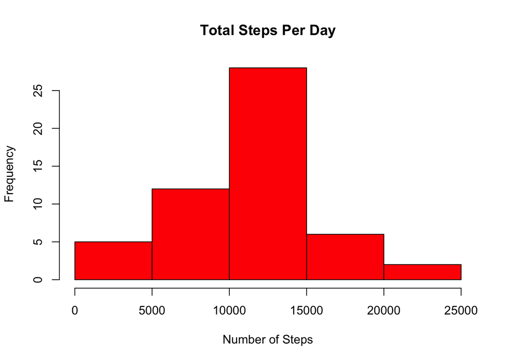

```r
hist(steps_per_day$steps, main = paste("Total Steps Per Day"), col = "red", xlab = "Number of Steps")
```

3. Mean & Median of total number of steps taken per day

```r
Mean_steps <- mean(steps_per_day$steps)
Mean_steps
```

```
## [1] 10766.19
```

```r
Median_steps <- median(steps_per_day$steps)
Median_steps
```

```
## [1] 10765
```

##What is the average daily activity pattern ?

1. Time serise plot

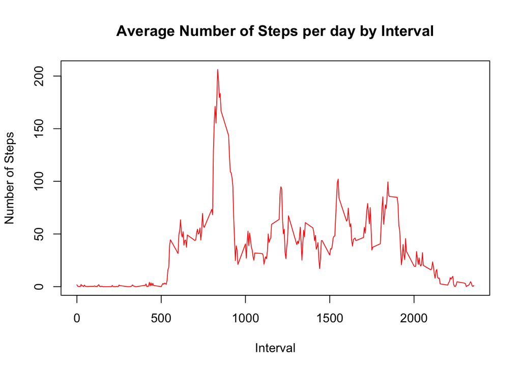

```r
steps_by_interval <- aggregate(steps ~ interval, data, mean)

plot(steps_by_interval$interval,steps_by_interval$steps, type="l", xlab="Interval", ylab="Number of Steps",main="Average Number of Steps per day by Interval", col="red")
```

2. maximum number of steps in 5 min interval

```r
max_steps_interval <- steps_by_interval[which.max(steps_by_interval$steps),1]
max_steps_interval
```

```
## [1] 835
```

##Imputing missing values

1. Calculate and report the total number of missing values in the dataset

```r
missing_values <- sum(!complete.cases(data))
missing_values
```

```
## [1] 2304
```

2. Filling all the missing values in the dataset

```r
AvgSteps <- aggregate(steps ~ interval, data = data, FUN = mean)

fill_missing <- numeric()
for (i in 1:nrow(data)) {
    obs <- data[i, ]
    if (is.na(obs$steps)) {
        steps <- subset(AvgSteps, interval == obs$interval)$steps
    } else {
        steps <- obs$steps
    }
    fill_missing <- c(fill_missing, steps)
}
```

3. Create a new dataset that is equal to the original dataset but with the missing data filled in

```r
new_dataset <- data
new_dataset$steps <- fill_missing
```

4. Histogram of the total number of steps taken each day and Calculate and report the mean and median total number of steps taken per day

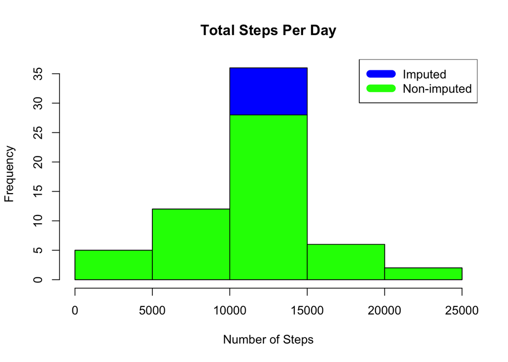

```r
Total_steps <- aggregate(steps ~ date, data = new_dataset, sum, na.rm = TRUE)
hist(Total_steps$steps, main = paste("Total Steps Per Day"), col="blue", xlab="Number of Steps")

#Histogram to show difference.

hist(steps_per_day$steps, main = paste("Total Steps Per Day"), col="green", xlab="Number of Steps", add=T)

legend("topright", c("Imputed", "Non-imputed"), col=c("blue", "green"), lwd=10)
```

calculate Mean

```r
mean_total <- mean(Total_steps$steps)
mean_total
```

```
## [1] 10766.19
```

calculate Median

```r
median_total <- median(Total_steps$steps)
median_total
```

```
## [1] 10766.19
```

Differencce from the estimates from the first part of the assignment?

```r
mean_difference <- mean_total - Mean_steps
mean_difference
```

```
## [1] 0
```

```r
median_difference <- median_total - Median_steps
median_difference
```

```
## [1] 1.188679
```

##Are there differences in activity patterns between weekdays and weekends?

1. New factor variable in the dataset with two levels – “weekday” and “weekend” indicating whether a given date is a weekday or weekend day.

```r
weekdays <- c("Monday", "Tuesday", "Wednesday", "Thursday", "Friday")

new_dataset$dow = as.factor(ifelse(is.element(weekdays(as.Date(new_dataset$date)),weekdays), "Weekday", "Weekend"))

Total_steps <- aggregate(steps ~ interval + dow, new_dataset, mean)
```

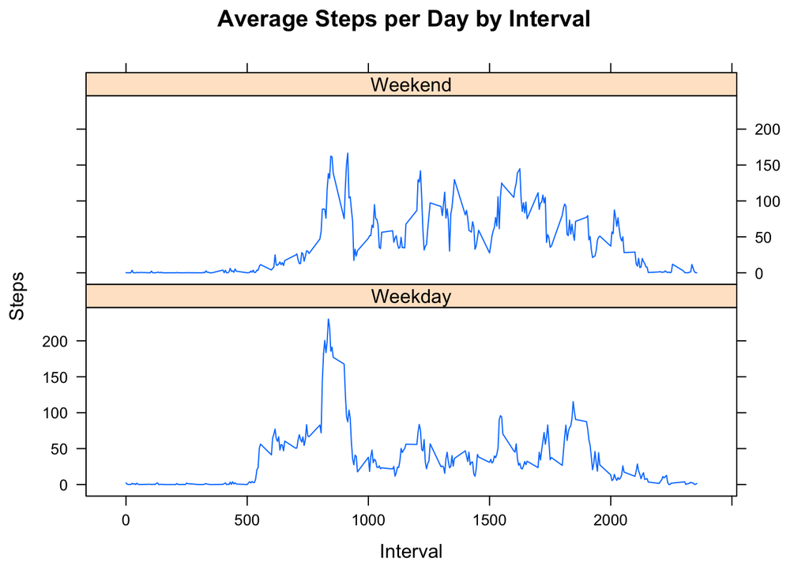

```r
library(lattice)

xyplot(Total_steps$steps ~ Total_steps$interval | Total_steps$dow, main="Average Steps per Day by Interval",xlab="Interval", ylab="Steps",layout=c(1,2), type="l")
```